# Explore 1000 genomics data using unsupervised learning methods

# Introduction

The 1000 Genomes Project is a landmark international collaboration that produced the most comprehensive public catalogue of human genetic variation to date. It contains the genome sequencing of 2,504 individuals from 26 diverse populations around the world. All data are freely available on the official website, providing an essential baseline for studies of population genetics, disease‐association mapping, and functional genomics. In this project, we explore the genetic dataset using unsupervising learning methods.

## Load data and packages

### Install & load required libraries

The following code chunk will load required libraries. If you don’t already have these installed, you’ll first need to install them (recommended way is to use `BiocManager::install("packageName")`).

```r
if (!requireNamespace("BiocManager", quietly=TRUE))
    install.packages("BiocManager")
BiocManager::install("gdsfmt")
BiocManager::install("SNPRelate")
```

```r
library(gdsfmt) # provides the genomic data structure (GDS) file format for array-oriented bioinformatic data, which is a container for storing annotation data and SNP genotypes
library(SNPRelate) #Read SNP data and perform PCA
```

```r
library(ggplot2)
library(dplyr)
library(kableExtra)
library(Rtsne) #t-SNE
library(pheatmap)
library(cluster)
theme_set(theme_bw()) # prettier ggplot plots
```

### Download and read the data into R

```r
# Convert the plink format to GDS format used for the package.
snpgdsBED2GDS(bed.fn = "data/1000genomicMerge.bed",
              bim.fn = "data/1000genomicMerge.bim",
              fam.fn = "data/1000genomicMerge.fam",
              out.gdsfn = "data/1000genomic.gds")
```

```r
genofile <- snpgdsOpen("data/1000genomic.gds") #read the genotype file
genofile
```

```
## File: C:\Users\gordo\Documents\GitHub\Bioinformatics\Gene expression clustering\data\1000genomic.gds (272.6M)
## +    [  ] *
## |--+ sample.id   { Str8 2504 LZMA_ra(7.66%), 1.5K }
## |--+ snp.id   { Str8 451155 LZMA_ra(26.7%), 1.9M }
## |--+ snp.position   { Int32 451155 LZMA_ra(54.2%), 954.4K }
## |--+ snp.chromosome   { UInt8 451155 LZMA_ra(0.07%), 301B } *
## |--+ snp.allele   { Str8 451155 LZMA_ra(20.7%), 446.9K }
## |--+ genotype   { Bit2 2504x451155, 269.3M } *
## \--+ sample.annot   [ data.frame ] *
##    |--+ sex   { Str8 2504 LZMA_ra(3.91%), 105B }
##    \--+ phenotype   { Int32 2504 LZMA_ra(1.26%), 133B }
```

```r
PED <- read.table('data/20130606_g1k.ped', header = TRUE, skip = 0, sep = '\t') #Read in the population information file

geno <- snpgdsGetGeno(genofile, snpfirstdim = FALSE, with.id = TRUE)
```

```
## Genotype matrix: 2504 samples X 451155 SNPs
```

```r
tab <- data.frame(sample.id = geno$sample.id)
tab <- left_join(tab, PED, by = c("sample.id" = "Individual.ID"))
# Assigning the superpopulation group by browsering information from: http://www.internationalgenome.org/category/population/
tab <- tab %>%
  mutate(superpop = case_when(
    Population %in% c("ESN", "MSL", "YRI", "LWK", "GWD") ~ "African",
    Population %in% c("ASW", "ACB", "MXL", "PUR", "CLM", "PEL") ~ "Latin American",
    Population %in% c("CEU", "TSI", "GBR", "FIN", "IBS") ~ "European",
    Population %in% c("CHB", "JPT", "CHS", "CDX", "KHV", "CHD") ~ "East Asian",
    Population %in% c("GIH", "PJL", "BEB", "STU", "ITU") ~ "South Asian"))  %>%
  mutate(superpop = as.factor(superpop))
table(tab$superpop)
```

```
##
##        African     East Asian       European Latin American    South Asian
##            504            504            503            504            489
```

```r
geno$superpop <- tab$superpop
geno$population <- tab$Population
```

The table lists the number of each population, where the detailed description can be found on the website.

# Dimension reduction

## PCA

The common way to explore high-dimensional data is by using principal component analysis(PCA). PCA is a dimensional reduction technique which preserves the dimensions with the largest variance in the data. It is a useful initial means of finding hidden structures in the data, and also to determine the important sources of variance.

```r
pca <- snpgdsPCA(genofile, num.thread=8) #Perform the principal component analysis
```

```
## Principal Component Analysis (PCA) on genotypes:
## Excluding 0 SNP on non-autosomes
## Excluding 0 SNP (monomorphic: TRUE, MAF: NaN, missing rate: NaN)
##     # of samples: 2,504
##     # of SNPs: 451,155
##     using 8 threads
##     # of principal components: 32
## PCA:    the sum of all selected genotypes (0,1,2) = 478640888
## CPU capabilities: Double-Precision SSE2
## Tue May 13 16:30:05 2025    (internal increment: 808)
## [..................................................]  0%, ETC: ---        [==================================================] 100%, completed, 1.1m
## Tue May 13 16:31:08 2025    Begin (eigenvalues and eigenvectors)
## Tue May 13 16:31:12 2025    Done.
```

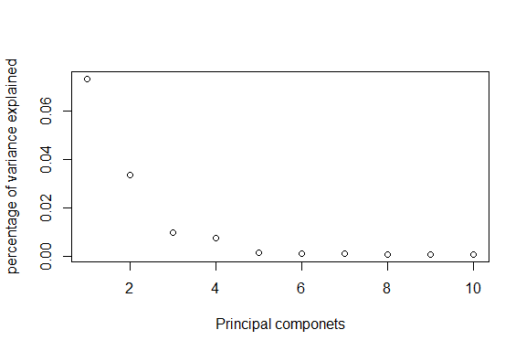

```r
plot(pca$varprop[1:10], xlab = "Principal componets", ylab = "percentage of variance explained")
```

```r
tab <- data.frame(sample.id = pca$sample.id,
    EV1 = pca$eigenvect[,1],    # the first eigenvector
    EV2 = pca$eigenvect[,2],    # the second eigenvector
    EV3 = pca$eigenvect[,3],
    EV4 = pca$eigenvect[,4],
    stringsAsFactors = FALSE)
tab <- left_join(tab,PED, by = c("sample.id" = "Individual.ID"))

# Assigning the superpopulation group by browsering information from: http://www.internationalgenome.org/category/population/
tab <- tab %>%
  mutate(superpop = case_when(
    Population %in% c("ESN", "MSL", "YRI", "LWK", "GWD") ~ "African",
    Population %in% c("ASW", "ACB", "MXL", "PUR", "CLM", "PEL") ~ "Latin American",
    Population %in% c("CEU", "TSI", "GBR", "FIN", "IBS") ~ "European",
    Population %in% c("CHB", "JPT", "CHS", "CDX", "KHV", "CHD") ~ "East Asian",
    Population %in% c("GIH", "PJL", "BEB", "STU", "ITU") ~ "South Asian"))  %>%
  mutate(superpop = as.factor(superpop))
```

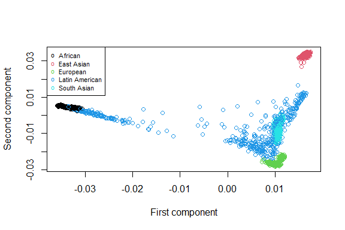

```r
# Draw
plot(tab$EV1, tab$EV2, col=as.integer(tab$superpop), xlab="First component", ylab="Second component" )
legend("topleft", legend=levels(tab$superpop), pch="o", col=1:nlevels(tab$superpop), cex = 0.7)
```

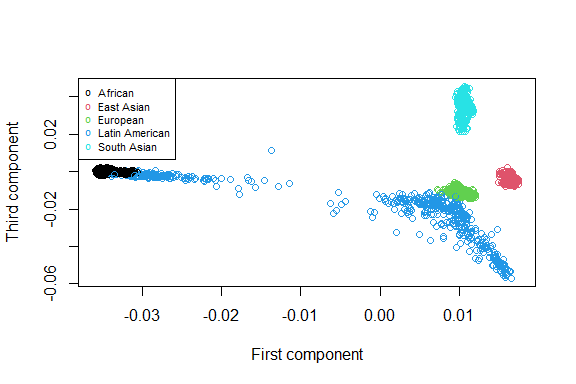

```r
plot(tab$EV1, tab$EV3, col=as.integer(tab$superpop), xlab="First component", ylab="Third component" )
legend("topleft", legend=levels(tab$superpop), pch="o", col=1:nlevels(tab$superpop), cex = 0.7)
```

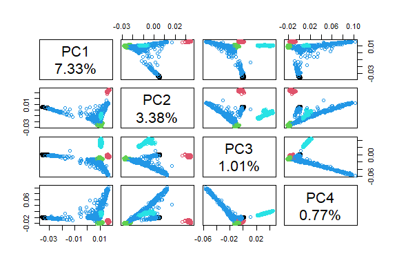

```r
lbls <- paste("PC", 1:4, "\n", format(pca$varprop[1:4] * 100, digits=2), "%", sep="")
pairs(pca$eigenvect[,1:4], col=tab$superpop, labels=lbls)
```

We observe that the superpopulations are mostly clustered in groups when visualizing the first and the third principal components. We also observe that there is a wider spread of the first component among Latin Americans. Some are more similar to European, while some are closer to African. This can be attributed to greater genetic diversity among Latin Americans due to historical migration and population mixing.

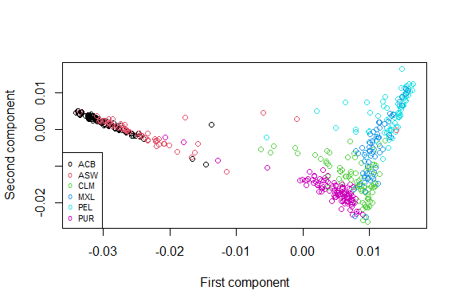

```r
tab_Latin <- subset(tab, superpop == "Latin American") %>%
  mutate(Population = as.factor(Population))

plot(tab_Latin$EV1, tab_Latin$EV2, col=as.integer(tab_Latin$Population), xlab="First component", ylab="Second component")
legend("bottomleft", legend=levels(tab_Latin$Population), pch="o", col=1:nlevels(tab_Latin$Population), cex = 0.7)
```

Given that ASW are of African Ancestry in the Southwest US and ACB are of African Caribbean in Barbados, it is unsurprising to see the overlaps with African superpopulation from the PCA plot. We also found some overlaps between PUR(Puerto Rican), CLM(Colombina) and European superpopulation.

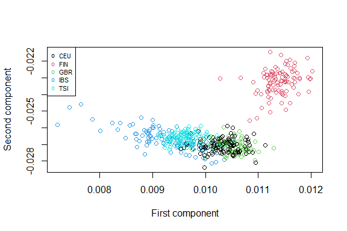

```r
tab_EUR <- subset(tab, superpop == "European") %>%
  mutate(Population = as.factor(Population))

plot(tab_EUR$EV1, tab_EUR$EV2, col=as.integer(tab_EUR$Population), xlab="First component", ylab="Second component")
legend("topleft", legend=levels(tab_EUR$Population), pch="o", col=1:nlevels(tab_EUR$Population), cex = 0.7)
```

## t-SNE

Another method that is an alternative to PCA is t-SNE. In contrast to PCA, it accounts for non-linear interactions between the features.

```r
tSNE <- Rtsne(geno$genotype,verbose = TRUE,partial_pca = TRUE)
```

```
## Performing PCA
## Read the 2504 x 50 data matrix successfully!
## OpenMP is working. 1 threads.
## Using no_dims = 2, perplexity = 30.000000, and theta = 0.500000
## Computing input similarities...
## Building tree...
## Done in 0.34 seconds (sparsity = 0.045037)!
## Learning embedding...
## Iteration 50: error is 74.108297 (50 iterations in 0.18 seconds)
## Iteration 100: error is 59.936121 (50 iterations in 0.15 seconds)
## Iteration 150: error is 57.645354 (50 iterations in 0.15 seconds)
## Iteration 200: error is 56.622764 (50 iterations in 0.14 seconds)
## Iteration 250: error is 55.959865 (50 iterations in 0.15 seconds)
## Iteration 300: error is 1.344077 (50 iterations in 0.14 seconds)
## Iteration 350: error is 1.043354 (50 iterations in 0.14 seconds)
## Iteration 400: error is 0.897769 (50 iterations in 0.14 seconds)
## Iteration 450: error is 0.820682 (50 iterations in 0.14 seconds)
## Iteration 500: error is 0.780396 (50 iterations in 0.14 seconds)
## Iteration 550: error is 0.757609 (50 iterations in 0.14 seconds)
## Iteration 600: error is 0.743914 (50 iterations in 0.14 seconds)
## Iteration 650: error is 0.733261 (50 iterations in 0.14 seconds)
## Iteration 700: error is 0.724749 (50 iterations in 0.14 seconds)
## Iteration 750: error is 0.718748 (50 iterations in 0.14 seconds)
## Iteration 800: error is 0.713221 (50 iterations in 0.14 seconds)
## Iteration 850: error is 0.706759 (50 iterations in 0.14 seconds)
## Iteration 900: error is 0.702079 (50 iterations in 0.14 seconds)
## Iteration 950: error is 0.696156 (50 iterations in 0.14 seconds)
## Iteration 1000: error is 0.694277 (50 iterations in 0.14 seconds)
## Fitting performed in 2.85 seconds.
```

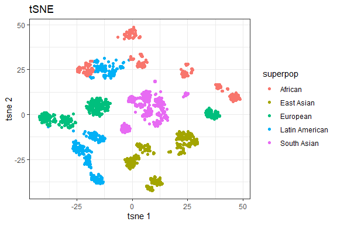

```r
as.data.frame(tSNE$Y) %>%
  mutate(population = geno$population) %>%
  mutate(superpop = geno$superpop) %>%
  ggplot(aes(x = V1, y = V2, colour = superpop)) +
    geom_point() +
    xlab("tsne 1") +
    ylab("tsne 2") +
    ggtitle("tSNE")
```

# Clustering

## Hierarchical Clustering

Perform clustering based on the top 10 principal components of genetic matrix.

```r
distance <- dist(pca$eigenvect[, 1:10], method = 'euclidean') #Compute the Euclidean distance between each samples
str(distance)
```

```
##  'dist' num [1:3133756] 0.01155 0.01751 0.01546 0.00543 0.00935 ...
##  - attr(*, "Size")= int 2504
##  - attr(*, "Diag")= logi FALSE
##  - attr(*, "Upper")= logi FALSE
##  - attr(*, "method")= chr "euclidean"
##  - attr(*, "call")= language dist(x = pca$eigenvect[, 1:10], method = "euclidean")
```

then, compute hierarchical clustering using 4 different linkage types: complete, single, average and Wald, and plot them.

[figure not shown]

```r
pr.hc.s <- hclust(distance, method = 'single')
pr.hc.c <- hclust(distance, method = 'complete')
pr.hc.a <- hclust(distance, method = 'average')
pr.hc.w <- hclust(distance, method = 'ward.D')

# plot them
op <- par(mar = c(0,4,4,2), mfrow = c(2,2))

plot(pr.hc.s, labels = FALSE, main = "Single")
plot(pr.hc.c, labels = FALSE, main = "Complete")
plot(pr.hc.a, labels = FALSE, main = "Average")
plot(pr.hc.w, labels = FALSE, main = "Ward")
```

```r
par(op)
```

Find the 5 clusters based on the Ward linkage method.

```r
cluster_samples = cutree(pr.hc.w, k = 5)
table(cluster_samples, geno$superpop)
```

```
##
## cluster_samples African East Asian European Latin American South Asian
##               1       0          0      493            266         103
##               2       0         14       10             79         386
##               3       0        490        0              0           0
##               4     207          0        0            134           0
##               5     297          0        0             25           0
```

```r
cluster_samples = cutree(pr.hc.s, k = 5)
table(cluster_samples, geno$superpop)
```

```
##
## cluster_samples African East Asian European Latin American South Asian
##               1     207        490      493            397         103
##               2     297         14       10            104         386
##               3       0          0        0              1           0
##               4       0          0        0              1           0
##               5       0          0        0              1           0
```

The clustering based on the single linkage put most samples to the first cluster.

```r
cluster_samples = cutree(pr.hc.a, k = 5)
table(cluster_samples, geno$superpop)
```

```
##
## cluster_samples African East Asian European Latin American South Asian
##               1       0          0      491            137         102
##               2       0        490        2            132           1
##               3       0         14       10             79         386
##               4     207          0        0            131           0
##               5     297          0        0             25           0
```

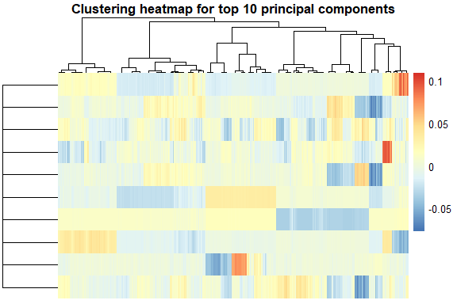

```r
# set pheatmap clustering parameters
clust_dist_col = "euclidean"
clust_method = "ward.D"
clust_scale = "none"

## the annotation option uses the covariate object (pData(geo_obj)). It must have the same rownames, as the colnames in our data object (expr_scaled).

pheatmap(t(pca$eigenvect[,1:10]),
         cluster_rows = TRUE,
         cluster_cols = TRUE,
         scale = clust_scale,
         clustering_method = clust_method,
         clustering_distance_cols = clust_dist_col,
         show_colnames = FALSE, show_rownames = FALSE,
         main = "Clustering heatmap for top 10 principal components",
         annotation = t(geno$superpop))
```

## K-mean clustering

Keep in mind that k-means makes certain assumptions about the data that may not always hold:  
- Variance of distribution of each variable is spherical  
- All variables have the same variance  
- A prior probability that all k clusters have the same number of members

One can argue that for genetic data, the assumption that all SNPs have the same variance is the most easily violated.

```r
set.seed(17)
k <- 5
pr.km <- kmeans(pca$eigenvect[, 1:10], centers = k, nstart =  50)

#We can look at the size of each cluster
pr.km$size
```

```
## [1] 713 739 504  99 449
```

```r
table(pr.km$cluster, geno$superpop)
```

```
##
##     African East Asian European Latin American South Asian
##   1       0          0      503            210           0
##   2     112          0        0            138         489
##   3       0        504        0              0           0
##   4      99          0        0              0           0
##   5     293          0        0            156           0
```

## PAM algorithm

In K-medoids clustering, K representative objects (medoids) are chosen as cluster centers and objects are assigned to the center (medoid = cluster) with which they have minimum dissimilarity (Kaufman and Rousseeuw, 1990).  
Nice features of partitioning around medoids (PAM) are: (a) it accepts a dissimilarity (distance) matrix (use `diss = TRUE`), (b) it is more robust to outliers as the centroids of the clusters are data objects, unlike k-means.

Here we run PAM with k = 5.

```r
pr.pam <- pam(distance, k = 5)
table(pr.pam$clustering, geno$superpop)
```

```
##
##     African East Asian European Latin American South Asian
##   1       0          0      488            173          66
##   2       0        490        5             92          37
##   3       0         14       10             76         386
##   4     207          0        0            135           0
##   5     297          0        0             28           0
```

We will now determine the optimal number of clusters, by looking at the average silhouette value. This is a statistic introduced in the PAM algorithm, which lets us identify a suitable k.

**The silhouette plot** The `cluster` package contains the function `silhouette()` that compares the minimum average dissimilarity (distance) of each object to other clusters **with** the average dissimilarity to objects in its own cluster. The resulting measure is called the “width of each object’s silhouette”. A value close to 1 indicates that the object is similar to objects in its cluster compared to those in other clusters. Thus, the average of all objects silhouette widths gives an indication of how well the clusters are defined.

[figure not shown]

```r
op <- par(mar = c(5,1,4,4))
plot(pr.pam, main = "Silhouette Plot for 5 clusters")
```

```r
par(op)
```

```r
j <- 2:30
avg_width <- numeric(length(j))  # pre-allocate numeric vector
distance <- pca$eigenvect[, 1:10]

for (i in j) {
  pam_result <- pam(distance, k = i , diss = TRUE)  # ensure 'distance' is a dissimilarity matrix
  avg_width[i - 1] <- pam_result$silinfo$avg.width
}
```

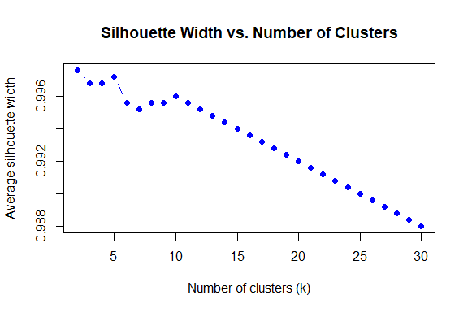

```r
plot(j, avg_width, type = "b", pch = 19, col = "blue",
     xlab = "Number of clusters (k)",
     ylab = "Average silhouette width",
     main = "Silhouette Width vs. Number of Clusters")
```

# Discussion

Novembre, John, Toby Johnson, Katarzyna Bryc, Zoltán Kutalik, Adam R. Boyko, Adam Auton, Amit Indap, et al. 2008. “Genes Mirror Geography Within Europe.” *Nature* 456 (7218): 98–101. https://doi.org/10.1038/nature07331.